# Prediction Assignment Writeup

Mike

November 23, 2018

This is my assignment on Practical Machine Learning by Coursera (John Hopkins University).

## Background and Objective

Using devices such as Jawbone Up, Nike FuelBand, and Fitbit it is now possible to collect a large amount of data about personal activity relatively inexpensively. These type of devices are part of the quantified self movement - a group of enthusiasts who take measurements about themselves regularly to improve their health, to find patterns in their behavior, or because they are tech geeks. One thing that people regularly do is quantify how much of a particular activity they do, but they rarely quantify how well they do it.

The goal will be to use data from accelerometers on the belt, forearm, arm, and dumbell of 6 participants. They were asked to perform barbell lifts correctly and incorrectly in 5 different ways.

## Loading required packages

All necessary packages should already loaded and the files should downloaded. We should clean the missing data (NA) and missing values in training data sets. Those values are useless and can be disregarded

## Partition of Data

We will now partition our data into a training data set and a testing data set (60% and 40% of the total cases respectively)

```
## [1] 19622    53
```

```
## [1] 20 53
```

```r
set.seed(12345)

Train <- createDataPartition(dtraining$classe, p=0.6, list=FALSE)
training <- dtraining[Train,]
testing <- dtraining[-Train,]

dim(training); dim(testing);
```

```
## [1] 11776    53
```

```
## [1] 7846   53
```

## Prediction MOdelling

We will now building a Random Forest Model and Decison Tree

## Decision Tree

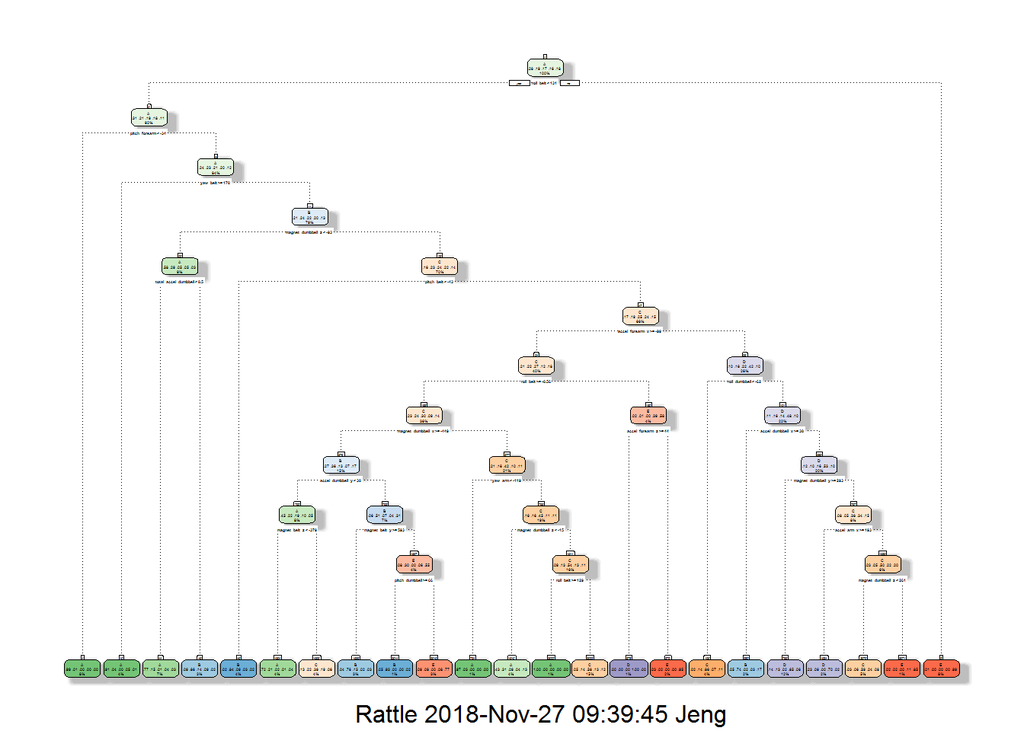

[output not shown]

[figure not shown]

```r
set.seed(301)
modFitDecTree <- rpart(classe ~ ., data=training, method="class")
fancyRpartPlot(modFitDecTree)
```

## Building a Random Forest Model

The out of sample error should be small when we use the Random Forest Model. The error will be estimated using the 40% testing sample.

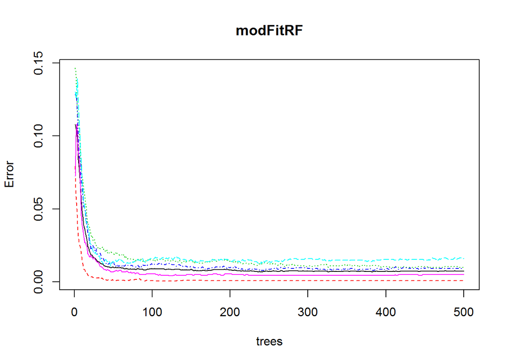

```r
set.seed(12345)

modFitRF <- randomForest(classe ~ ., data = training, method = "rf", importance = T, trControl = trainControl(method = "cv", classProbs=TRUE,savePredictions=TRUE,allowParallel=TRUE, number = 10))

plot(modFitRF)
```

## Predicting with Random Forest Model

```r
prediction <- predict(modFitRF, testing, type = "class")
confusionMatrix(prediction, testing$classe)
```

```
## Confusion Matrix and Statistics
##
##           Reference
## Prediction    A    B    C    D    E
##          A 2230    8    0    0    0
##          B    2 1505    6    0    0
##          C    0    5 1362   14    2
##          D    0    0    0 1270    3
##          E    0    0    0    2 1437
##
## Overall Statistics
##
##                Accuracy : 0.9946
##                  95% CI : (0.9928, 0.9961)
##     No Information Rate : 0.2845
##     P-Value [Acc > NIR] : < 2.2e-16
##
##                   Kappa : 0.9932
##  Mcnemar's Test P-Value : NA
##
## Statistics by Class:
##
##                      Class: A Class: B Class: C Class: D Class: E
## Sensitivity            0.9991   0.9914   0.9956   0.9876   0.9965
## Specificity            0.9986   0.9987   0.9968   0.9995   0.9997
## Pos Pred Value         0.9964   0.9947   0.9848   0.9976   0.9986
## Neg Pred Value         0.9996   0.9979   0.9991   0.9976   0.9992
## Prevalence             0.2845   0.1935   0.1744   0.1639   0.1838
## Detection Rate         0.2842   0.1918   0.1736   0.1619   0.1832
## Detection Prevalence   0.2852   0.1928   0.1763   0.1622   0.1834
## Balanced Accuracy      0.9988   0.9951   0.9962   0.9936   0.9981
```

## Choosing the Model in Predicting to test the data

```r
predictTEST <- predict(modFitRF, newdata=testing)
predictTEST
```

[output not shown]

[output cut: 1254 more lines]

[output not shown]